# GoBike Dataset Exploration

## Preliminary Wrangling

> The dataset contains 183412 bike rentals records.

```python
# import all packages and set plots to be embedded inline
import numpy as np
import pandas as pd
import matplotlib.pyplot as plt
import seaborn as sb
%matplotlib inline
```

```python
df= pd.read_csv("201902-fordgobike-tripdata.csv")
df.head()
```

|  | duration_sec | start_time | end_time | start_station_id | start_station_name | start_station_latitude | start_station_longitude | end_station_id | end_station_name | end_station_latitude | end_station_longitude | bike_id | user_type | member_birth_year | member_gender | bike_share_for_all_trip |
| --- | --- | --- | --- | --- | --- | --- | --- | --- | --- | --- | --- | --- | --- | --- | --- | --- |
| 0 | 52185 | 2019-02-28 17:32:10.1450 | 2019-03-01 08:01:55.9750 | 21.0 | Montgomery St BART Station (Market St at 2nd St) | 37.789625 | -122.400811 | 13.0 | Commercial St at Montgomery St | 37.794231 | -122.402923 | 4902 | Customer | 1984.0 | Male | No |
| 1 | 42521 | 2019-02-28 18:53:21.7890 | 2019-03-01 06:42:03.0560 | 23.0 | The Embarcadero at Steuart St | 37.791464 | -122.391034 | 81.0 | Berry St at 4th St | 37.775880 | -122.393170 | 2535 | Customer | NaN | NaN | No |
| 2 | 61854 | 2019-02-28 12:13:13.2180 | 2019-03-01 05:24:08.1460 | 86.0 | Market St at Dolores St | 37.769305 | -122.426826 | 3.0 | Powell St BART Station (Market St at 4th St) | 37.786375 | -122.404904 | 5905 | Customer | 1972.0 | Male | No |
| 3 | 36490 | 2019-02-28 17:54:26.0100 | 2019-03-01 04:02:36.8420 | 375.0 | Grove St at Masonic Ave | 37.774836 | -122.446546 | 70.0 | Central Ave at Fell St | 37.773311 | -122.444293 | 6638 | Subscriber | 1989.0 | Other | No |
| 4 | 1585 | 2019-02-28 23:54:18.5490 | 2019-03-01 00:20:44.0740 | 7.0 | Frank H Ogawa Plaza | 37.804562 | -122.271738 | 222.0 | 10th Ave at E 15th St | 37.792714 | -122.248780 | 4898 | Subscriber | 1974.0 | Male | Yes |

```python
df.info()
```

```
<class 'pandas.core.frame.DataFrame'>
RangeIndex: 183412 entries, 0 to 183411
Data columns (total 16 columns):
 #   Column                   Non-Null Count   Dtype
---  ------                   --------------   -----
 0   duration_sec             183412 non-null  int64
 1   start_time               183412 non-null  object
 2   end_time                 183412 non-null  object
 3   start_station_id         183215 non-null  float64
 4   start_station_name       183215 non-null  object
 5   start_station_latitude   183412 non-null  float64
 6   start_station_longitude  183412 non-null  float64
 7   end_station_id           183215 non-null  float64
 8   end_station_name         183215 non-null  object
 9   end_station_latitude     183412 non-null  float64
 10  end_station_longitude    183412 non-null  float64
 11  bike_id                  183412 non-null  int64
 12  user_type                183412 non-null  object
 13  member_birth_year        175147 non-null  float64
 14  member_gender            175147 non-null  object
 15  bike_share_for_all_trip  183412 non-null  object
dtypes: float64(7), int64(2), object(7)
memory usage: 22.4+ MB
```

```python
df['start_time']=pd.to_datetime(df['start_time'], format='%Y-%m-%d %H:%M:%S')
df['end_time']=pd.to_datetime(df['end_time'], format='%Y-%m-%d %H:%M:%S')
```

```python
df.describe()
```

|  | duration_sec | start_station_id | start_station_latitude | start_station_longitude | end_station_id | end_station_latitude | end_station_longitude | bike_id | member_birth_year |
| --- | --- | --- | --- | --- | --- | --- | --- | --- | --- |
| count | 183412.000000 | 183215.000000 | 183412.000000 | 183412.000000 | 183215.000000 | 183412.000000 | 183412.000000 | 183412.000000 | 175147.000000 |
| mean | 726.078435 | 138.590427 | 37.771223 | -122.352664 | 136.249123 | 37.771427 | -122.352250 | 4472.906375 | 1984.806437 |
| std | 1794.389780 | 111.778864 | 0.099581 | 0.117097 | 111.515131 | 0.099490 | 0.116673 | 1664.383394 | 10.116689 |
| min | 61.000000 | 3.000000 | 37.317298 | -122.453704 | 3.000000 | 37.317298 | -122.453704 | 11.000000 | 1878.000000 |
| 25% | 325.000000 | 47.000000 | 37.770083 | -122.412408 | 44.000000 | 37.770407 | -122.411726 | 3777.000000 | 1980.000000 |
| 50% | 514.000000 | 104.000000 | 37.780760 | -122.398285 | 100.000000 | 37.781010 | -122.398279 | 4958.000000 | 1987.000000 |
| 75% | 796.000000 | 239.000000 | 37.797280 | -122.286533 | 235.000000 | 37.797320 | -122.288045 | 5502.000000 | 1992.000000 |
| max | 85444.000000 | 398.000000 | 37.880222 | -121.874119 | 398.000000 | 37.880222 | -121.874119 | 6645.000000 | 2001.000000 |

```python
df[['start_station_id', 'end_station_id']].nunique()
```

```
start_station_id    329
end_station_id      329
dtype: int64
```

### What is the structure of your dataset?

> The data consists of 183412 rows each representing a rental record. For each rental, the start and end station coordinates and id are recorded as well as the ride start time, end time and duration of the ride. The bike id is also recorded as well as some basic customer demographics such as birth year, gender and whether they are subscribed or not. Some variables are numerical such as times and coordinates, some are categorical such as gender(Male, Female, Other) and user type(Subscriber, Customer).

### What is/are the main feature(s) of interest in your dataset?

> features of interest are whether there is a relatiosnship between customer type or gender and rental patterns.

### What features in the dataset do you think will help support your investigation into your feature(s) of interest?

> user_type, member_gender and counts.

## Univariate Exploration

> In this section, I will be looking at how different variables are distributed.

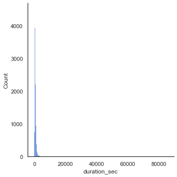

```python
sb.displot(data=df, x='duration_sec');
```

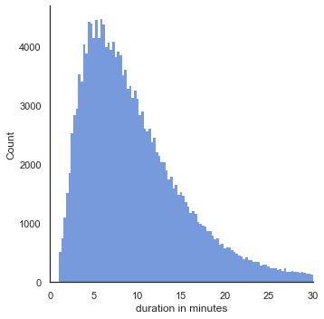

```python
sb.displot(data=df, x=df['duration_sec']/60);
plt.xlim(0,30);
plt.xlabel('duration in minutes');
```

> In the above diagrams, the first shows shows the distribution of duration in seconds and the second zooms in on the range where the majorty of data falls and converts the units to minutes to make the plot more directly informative.

> The vast majority of trips take less than 30 minutes and more specifically most are in the range below 15 minutes.

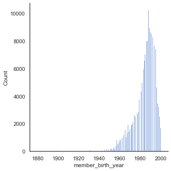

```python
sb.displot(data=df, x='member_birth_year')
```

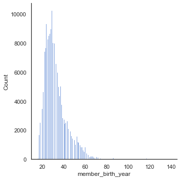

```python
sb.displot(data=df, x=2017-df['member_birth_year'])
```

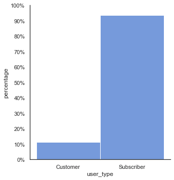

```python
sb.displot(data=df, x='user_type')
max_perc = df.dropna()['user_type'].value_counts().max()/df.dropna().shape[0]
tick_vals = np.arange(0,max_perc+0.1, 0.1)
tick_labels = ['{:0.0f}%'.format(v) for v in tick_vals*100 ]
plt.yticks(tick_vals*df.dropna().shape[0], tick_labels)
plt.ylabel('percentage');
```

> We can here see that over 90% od users are subscribers.

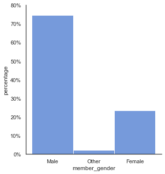

```python
sb.displot(data=df.dropna(), x='member_gender')
max_perc = df.dropna()['member_gender'].value_counts().max()/df.dropna().shape[0]
tick_vals = np.arange(0,max_perc+0.1, 0.1)
tick_labels = ['{:0.0f}%'.format(v) for v in tick_vals*100 ]
plt.yticks(tick_vals*df.dropna().shape[0], tick_labels)
plt.ylabel('percentage');
```

> Over 70% of users are males. However, there are also missing records where the users did not specify their gender.

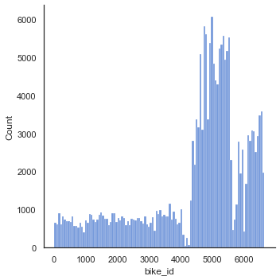

```python
sb.displot(data=df, x='bike_id')
```

> The figure shows a clear variation of how often different bikes are rented. There seem to be approximately two levels which could corelate with difference in bike type but since there is no further related data, it would be hard to draw conclusions about this point fom this dataset alone.

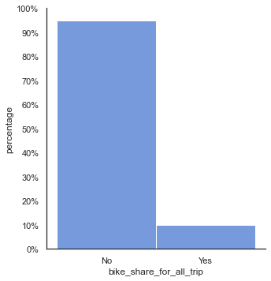

```python
sb.displot(data=df, x='bike_share_for_all_trip')
max_perc = df.dropna()['bike_share_for_all_trip'].value_counts().max()/df.dropna().shape[0]
tick_vals = np.arange(0,max_perc+0.1, 0.1)
tick_labels = ['{:0.0f}%'.format(v) for v in tick_vals*100 ]
plt.yticks(tick_vals*df.dropna().shape[0], tick_labels)
plt.ylabel('percentage');
```

> Over 90% of trips do not include bike share.

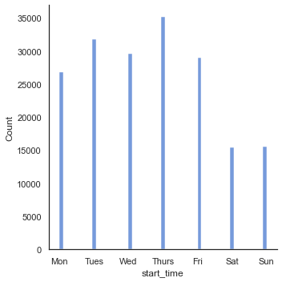

```python
sb.displot(data=df, x=df['start_time'].dt.dayofweek)
plt.xticks([0,1,2,3,4,5,6], labels=["Mon", "Tues", "Wed", "Thurs", "Fri", "Sat", "Sun"]);
```

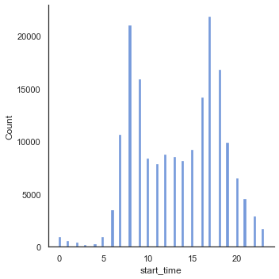

```python
sb.displot(data=df, x=df['start_time'].dt.hour)
```

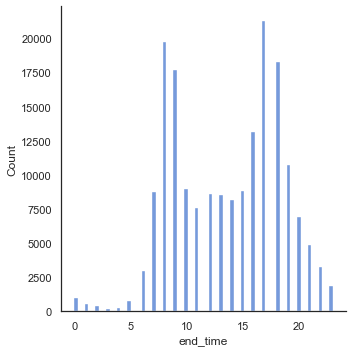

```python
sb.displot(data=df, x=df['end_time'].dt.hour)
```

> From the day of week and hour diagrams, we can observe that most rentals are made during weekdays and they are much less on weekends. We can also see that rentals peak around 8-9 am and again around 5 pm. From these two observations we can see that most people use the rented bike for commute to or from work.

### Discuss the distribution(s) of your variable(s) of interest. Were there any unusual points? Did you need to perform any transformations?

> There was a distinct pattern in rentals manifesting in a large drop in rentals over the weekend as well as peaks in the morning and the afternoon. An intersting distribution was that of ride durations as most rides are short only lasting less than 15 minutes.

### Of the features you investigated, were there any unusual distributions? Did you perform any operations on the data to tidy, adjust, or change the form of the data? If so, why did you do this?

> Some gender data was missing so in related plots, the rows containing missing values were dropped. To display the time in an informative way, the data had to be converted to datetime format and different plots used different parts of the information such as the hour or the day of the week.

## Bivariate Exploration

> In this section, I will be investigating some of the relationships in the data.

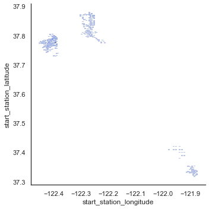

```python
sb.displot(data=df, y='start_station_latitude', x='start_station_longitude')
```

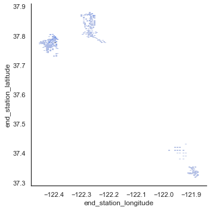

```python
sb.displot(data=df, y='end_station_latitude', x='end_station_longitude')
```

> The two plots above show the distribution of locations of rental stations and there seems to be a higher concentration of rentals in the northwestern cluster of stations.

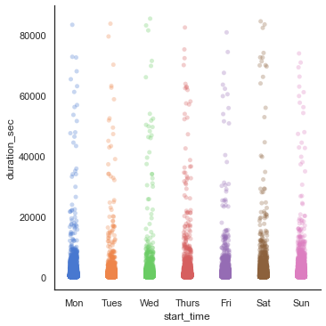

```python
sb.catplot(data=df, x=df['start_time'].dt.dayofweek, y='duration_sec', alpha=0.3)
plt.xticks([0,1,2,3,4,5,6], labels=["Mon", "Tues", "Wed", "Thurs", "Fri", "Sat", "Sun"]);
```

```
(0.0, 1800.0)
```

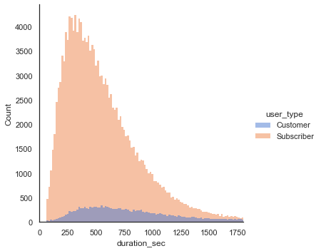

```python
sb.displot(data=df, x='duration_sec', hue='user_type')
plt.xlim(0,1800)
```

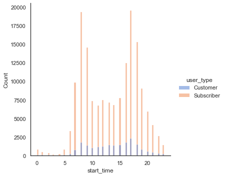

```python
sb.displot(data=df, x=df['start_time'].dt.hour, hue='user_type')
```

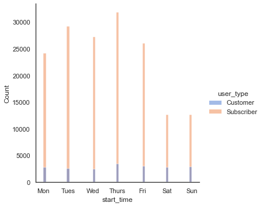

```python
sb.displot(data=df, x=df['start_time'].dt.dayofweek, hue='user_type')
plt.xticks([0,1,2,3,4,5,6], labels=["Mon", "Tues", "Wed", "Thurs", "Fri", "Sat", "Sun"]);
```

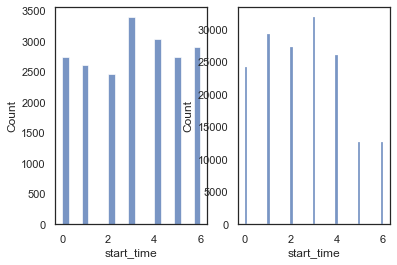

```python
fig, axes = plt.subplots(1,2)
sb.set(rc={"figure.figsize":(30, 7)}) #width=6, height=5
sb.histplot(data=df, x=df[df['user_type']=='Customer']['start_time'].dt.dayofweek, ax=axes[0])
sb.histplot(data=df, x=df[df['user_type']=='Subscriber']['start_time'].dt.dayofweek, ax=axes[1])
```

> There is no difference in usage trends between customers and subscribers throughout the day. However, while demand from subscribers drops during the weekend, customer usage is evenly distributed across weekdays.

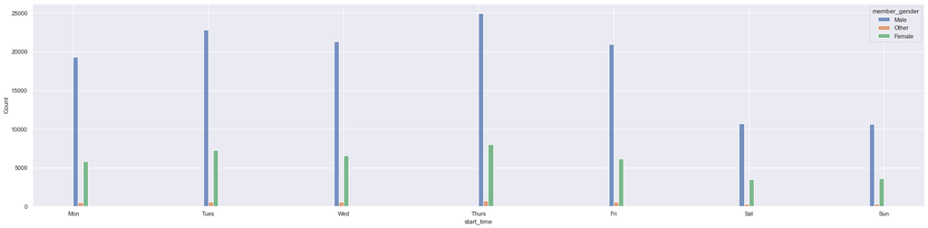

```python
sb.histplot(data=df, x=df['start_time'].dt.dayofweek, hue='member_gender', multiple='dodge')
plt.xticks([0,1,2,3,4,5,6], labels=["Mon", "Tues", "Wed", "Thurs", "Fri", "Sat", "Sun"]);
```

> There is no observable difference in weekly rental patterns between different genders.

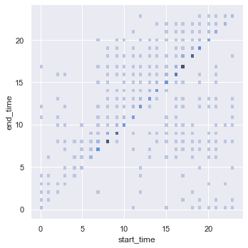

```python
sb.displot(data=df, x=df['start_time'].dt.hour, y=df['end_time'].dt.hour);
```

> Start time and end time are within the same hour in most of the cases which matches with the prior observation that most trips are less than an hour in duration.

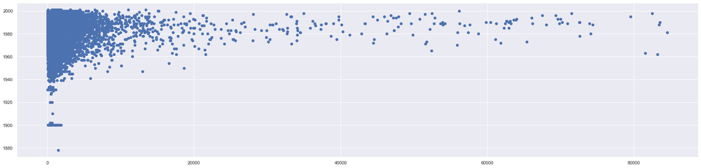

```python
plt.scatter(x=df['duration_sec'],y=df['member_birth_year'])
```

> Longer rides are more common in younger ge groups.

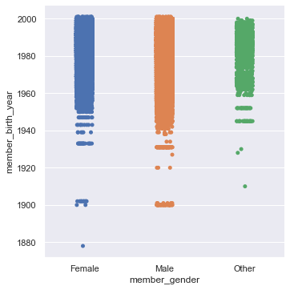

```python
sb.catplot(data=df.dropna(),x=df.dropna()['member_gender'].astype('category'),y=df.dropna()['member_birth_year'])
```

> There are slightly more older male users of ages above 60 than non-male ones.

### Talk about some of the relationships you observed in this part of the investigation. How did the feature(s) of interest vary with other features in the dataset?

> Customers had a different rental pattern than that of subscribers across week days but similar patterns within the day. They also had same ride duration ranges as subscribers. Gender, on the other hand had no influence on rental rates in different times.

> Another point of interest is that the daily pattern of rentals for different hours persists across all week days

### Did you observe any interesting relationships between the other features (not the main feature(s) of interest)?

> There are more older male users than non-males of smiliar age groups.

## Multivariate Exploration

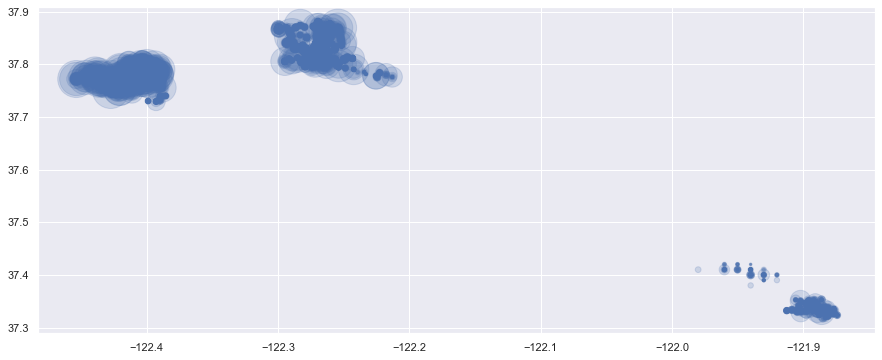

```python
fig_size = plt.rcParams["figure.figsize"]
plt.rcParams["figure.figsize"] = (15,6)
plt.scatter(df['start_station_longitude'],df['start_station_latitude'], s=df['duration_sec']/60, alpha=0.2);
```

> The plot aboe shows some regions have more loger rides than others

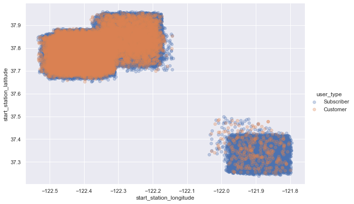

```python
k=sb.FacetGrid(data=df, hue='user_type', hue_order=['Subscriber', 'Customer'], height=6, aspect=1.5)
k.map(sb.regplot, 'start_station_longitude','start_station_latitude', x_jitter=0.08, y_jitter=0.08,fit_reg=False, scatter_kws={'alpha':0.3})
k.add_legend();
```

> The above plot shows the distribution of the different types of users and we can see some regions have more customers to subscribers ratio than others

```python
df['weeks']=df['start_time'].dt.dayofweek
```

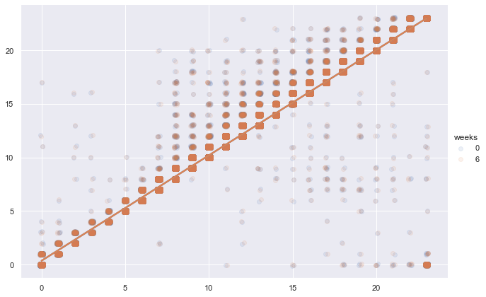

```python
k=sb.FacetGrid(data=df[(df['weeks']==0) |(df['weeks']==6)], hue='weeks', height=6, aspect=1.5)
k.map(sb.regplot, x=df['start_time'].dt.hour, y=df['end_time'].dt.hour, x_jitter=0.1, y_jitter=0.1,scatter_kws={'alpha':0.1})
k.add_legend();
```

> The figure above shows the usage for Monday and Sunday one of which a workday and the other is week end and the regression line shows no difference in the overall pattern of both.

```python
df['regions']= 1
df.loc[(df['start_station_longitude']>-122.35)& (df['start_station_longitude']<-122.05) & (df['start_station_latitude']>37.6),'regions']=2
df.loc[(df['start_station_longitude']>-122.05) & (df['start_station_latitude']<37.6),'regions']=3
```

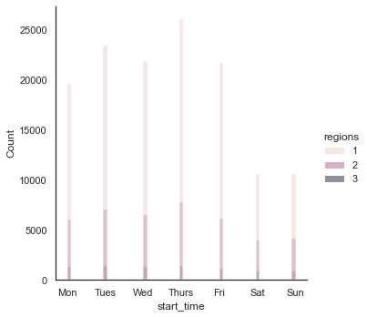

```python
sb.set_style("white")

sb.displot(data=df, x=df['start_time'].dt.dayofweek, hue='regions')
plt.xticks([0,1,2,3,4,5,6], labels=["Mon", "Tues", "Wed", "Thurs", "Fri", "Sat", "Sun"]);
```

> The above plot classifies the stations into 3 regions based on their latitude and longitude and plots the weekly rental pattern and it can be seen there is not significant difference in trends between regions.

### Talk about some of the relationships you observed in this part of the investigation. Were there features that strengthened each other in terms of looking at your feature(s) of interest?

> Weekly usage patterns are persistent in all areas. Surprisingly, there is no difference in start and end times between Monday and Sunday was also somewhat surprising since it was expected that peoplr's behaviour patterns can change during weekends.

### Were there any interesting or surprising interactions between features?

> Some areas have more longer trips than others. Interestingly, the places with more long rides also have a higher ratio of Customers to Subscribers which might be due to these places having more attractions.